# Lesson 3

### Labeling Plots

Notes:

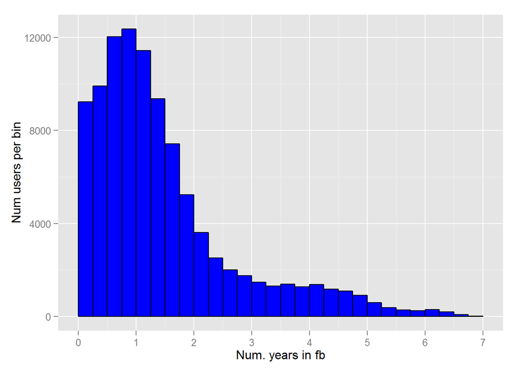

```r
qplot(data = pf, x = tenure/365,
      xlab = 'Num. years in fb',
      ylab = 'Num users per bin',
      color = I('black'), fill = I('blue'), binwidth = 0.25) +
  scale_x_continuous(limits = c(0, 7), breaks = seq(0, 7, 1))
```

### User Ages

Notes:

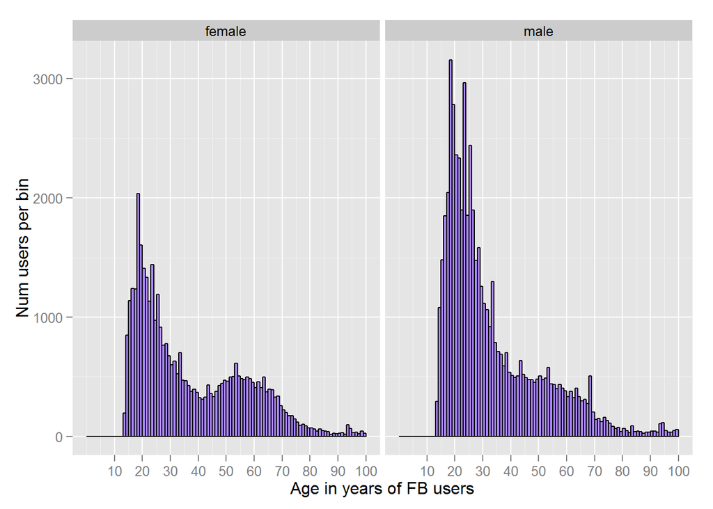

```r
qplot(data = na.omit(pf), x = age, binwidth = 1,
      xlab = 'Age in years of FB users', ylab = 'Num users per bin',
      color = I('black'), fill = I('#aa88ff')) +
  scale_x_continuous(limits = c(0, 100), breaks = seq(10, 100, 10)) +
  facet_wrap(~gender)
```

#### What do you notice?

Response: - Noticed that majority of users in the 20-30 age group - Also, there is spike in interest for 50-65 year olds. Grandma’s?

### The Spread of Memes

Notes:

### Lada’s Money Bag Meme

Notes:

### Transforming Data

Notes:

```r
summary(pf$friend_count)
```

```
##    Min. 1st Qu.  Median    Mean 3rd Qu.    Max.
##     0.0    31.0    82.0   196.4   206.0  4923.0
```

```r
summary(log10(pf$friend_count + 1))    # +1 is because log 0 will be -inf
```

```
##    Min. 1st Qu.  Median    Mean 3rd Qu.    Max.
##   0.000   1.505   1.919   1.868   2.316   3.692
```

### Add a Scaling Layer

Notes: http://lightonphiri.org/blog/ggplot2-multiple-plots-in-one-graph-using-gridextra - ggplot is also quite similar to qplot except wrapping x and y args within aes - aes stands for aesthetic - note that scale_x_log10() and scale_x_sqrt() can be used w/ qplot() as well

```r
library(gridExtra)
```

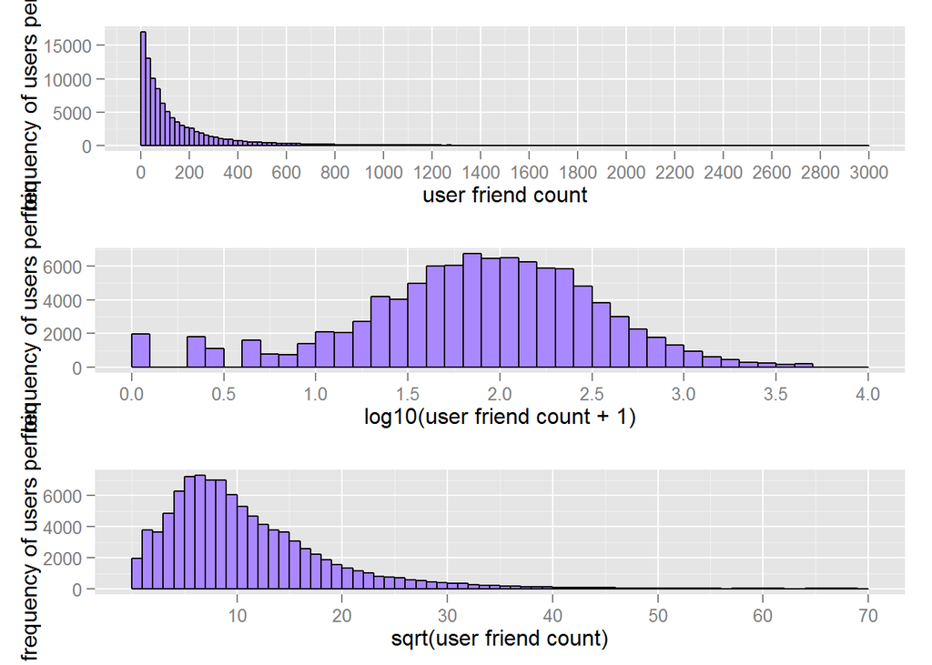

```r
p1 <- qplot(data = pf, x = friend_count, binwidth = 20,
      xlab = 'user friend count', ylab = 'frequency of users per bin',
      color = I('black'), fill = I('#aa88ff')) +
  scale_x_continuous(limits = c(0, 3000), breaks = seq(0,3000, 200))
# Amazing how log10 plot transformed into a normal distribution!
p2 <- qplot(data = pf, x = log10(friend_count+1), binwidth = 0.1,
      xlab = 'log10(user friend count + 1)', ylab = 'frequency of users per bin',
      color = I('black'), fill = I('#aa88ff')) +
  scale_x_continuous(limits = c(0, 4), breaks = seq(0, 4, 0.5))

p3 <- qplot(data = pf, x = sqrt(friend_count), binwidth = 1,
      xlab = 'sqrt(user friend count)', ylab = 'frequency of users per bin',
      color = I('black'), fill = I('#aa88ff')) +
  scale_x_continuous(limits = c(0, 70), breaks = seq(10, 70, 10))

grid.arrange(p1, p2, p3, ncol = 1)
```

```r
# ggplot syntax to do the same
# p4 <- ggplot(data = pf, aes(x = friend_count)) + geom_histogram()
# p5 <- p3 + scale_x_log10()          # notice that this is still labeling in x units
# p6 <- p3 + scale_x_sqrt()
# grid.arrange(p3, p4, p5, ncol = 1)
```

### Frequency Polygons

Notes: - Uses the geom arg for qplot - notice how y is set to change to proportion rather than absolute to compare male and female

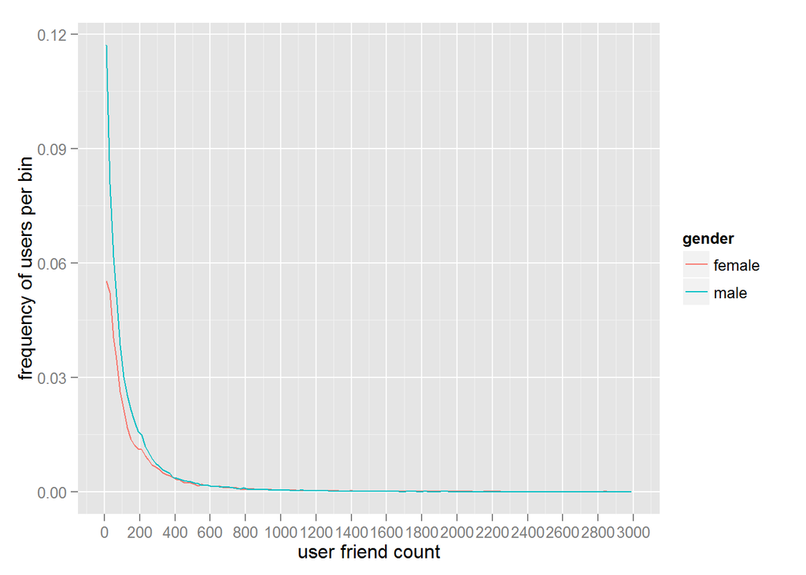

```r
qplot(data = subset(pf, !is.na(gender)), x = friend_count, y = ..count../sum(..count..),
      binwidth = 20, geom = 'freqpoly',
      xlab = 'user friend count', ylab = 'frequency of users per bin',
      color = gender) +
  scale_x_continuous(limits = c(0, 3000), breaks = seq(0,3000, 200))
```

```r
# + scale_y_continuous(limits = c(0, 0.005))   # to zoom into crossover of females over males
# happens around 800 friend_count
```

### Likes on the Web

Notes:

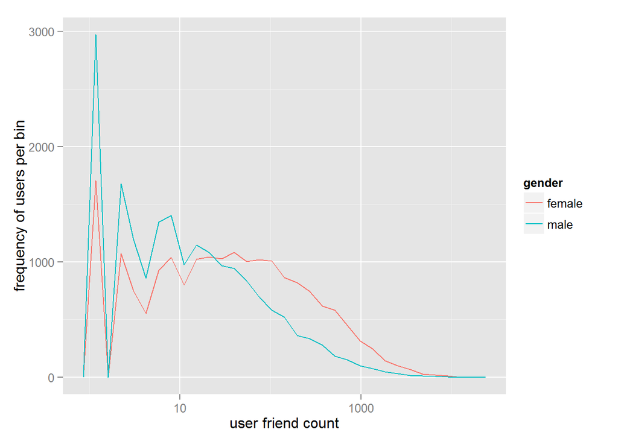

```r
qplot(data = subset(pf, !is.na(gender)), x = www_likes,
      geom = 'freqpoly',
      xlab = 'user friend count', ylab = 'frequency of users per bin',
      color = gender) +
  scale_x_log10()
```

### Likes on the web solution

```r
by(pf$www_likes, pf$gender, sum)
```

```
## pf$gender: female
## [1] 3507665
## --------------------------------------------------------
## pf$gender: male
## [1] 1430175
```

### Box Plots

Notes: - Remember that y is always the frequency that you want to count - x is always what you want to divide by

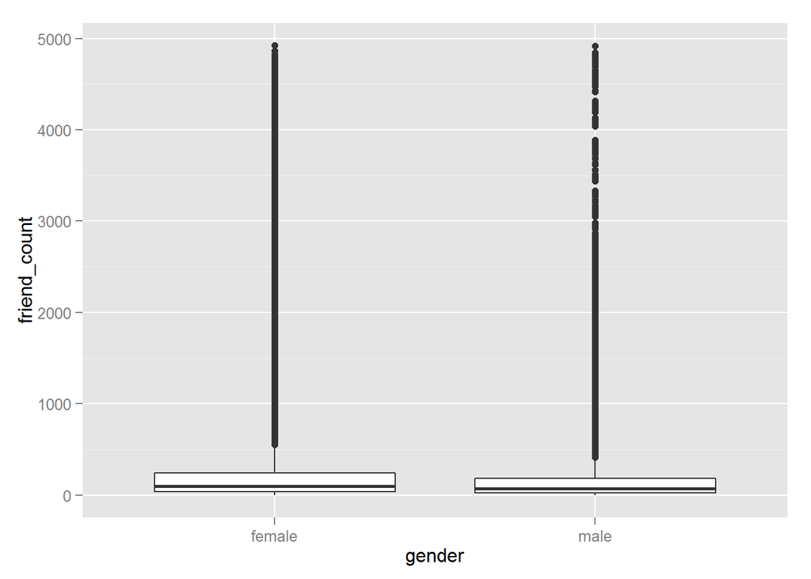

```r
qplot(data = subset(pf, !is.na(gender)),
      x = gender, y = friend_count,
      geom = 'boxplot')
```

#### Adjust the code to focus on users who have friend counts between 0 and 1000.

Notes: - Although, we may think the solution is to subset the data to get rid of outliers above 1000, that will change the nature of the boxplot itself which is WRONG! - Note that scale_y_continuous(limits = c(0, 1000)) and ylim variable have the same problem as well! - Correct way is to use coord_cartesian() to only adjust the axis

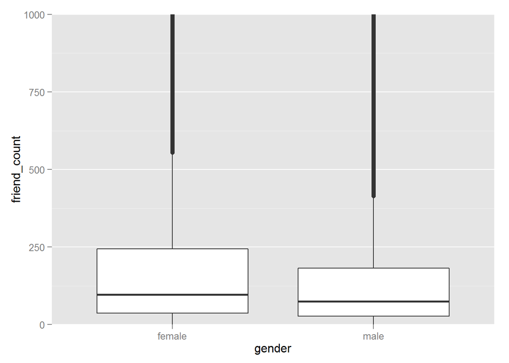

```r
# qplot(data = subset(pf, !is.na(gender) & friend_count <= 1000),
#      x = gender, y = friend_count,
#      geom = 'boxplot')
qplot(data = subset(pf, !is.na(gender)),
      x = gender, y = friend_count,
      geom = 'boxplot') +
  coord_cartesian(ylim = c(0, 1000))
```

### Box Plots, Quartiles, and Friendships

Notes: - Check that the summary matches our box plots after using coord_cartesian()

```r
by(pf$friend_count, pf$gender, summary)
```

```
## pf$gender: female
##    Min. 1st Qu.  Median    Mean 3rd Qu.    Max.
##       0      37      96     242     244    4923
## --------------------------------------------------------
## pf$gender: male
##    Min. 1st Qu.  Median    Mean 3rd Qu.    Max.
##       0      27      74     165     182    4917
```

#### On average, who initiated more friendships in our sample: men or women?

Response: Women #### Write about some ways that you can verify your answer. Response:

```r
by(pf$friendships_initiated, pf$gender, summary)
```

```
## pf$gender: female
##    Min. 1st Qu.  Median    Mean 3rd Qu.    Max.
##     0.0    19.0    49.0   113.9   124.8  3654.0
## --------------------------------------------------------
## pf$gender: male
##    Min. 1st Qu.  Median    Mean 3rd Qu.    Max.
##     0.0    15.0    44.0   103.1   111.0  4144.0
```

```r
by(pf$friendships_initiated, pf$gender, sum)    # although total is higher for men
```

```
## pf$gender: female
## [1] 4584894
## --------------------------------------------------------
## pf$gender: male
## [1] 6037023
```

Response: Both mean and median higher for women than men ***

### Getting Logical

Notes: - Important to change to factors to see summary for $mobile_checkins

```r
summary(pf$mobile_likes)
```

```
##    Min. 1st Qu.  Median    Mean 3rd Qu.    Max.
##     0.0     0.0     4.0   106.1    46.0 25110.0
```

```r
summary(pf$mobile_likes > 0)
```

```
##    Mode   FALSE    TRUE    NA's
## logical   35056   63947       0
```

```r
mobile_checkins <- NA
pf$mobile_checkins <- ifelse(pf$mobile_likes > 0, 1, 0)
pf$mobile_checkins <- factor(pf$mobile_checkins)
summary(pf$mobile_checkins)
```

```
##     0     1
## 35056 63947
```

```r
num <- sum(pf$mobile_checkins == 1)
den <- length((pf$mobile_checkins))
num * 100 / den
```

```
## [1] 64.59097
```

Response: *** Almost 65% of the users have used mobile checkins. This means that continuing to develop FB app for mobile platform is very important.

### Analyzing One Variable

Reflection: